# Formulas in R

Niels Richard Hansen

February 4, 2016

R provides a formula interface to linear models via the function `lm` and to generalized linear models via the function `glm`. That is, instead of specifying the matrix $\mathbf{X}$ explicitly, it is derived from a formula. This is very convenient, and it allows us to focus on variables instead of how they are encoded as columns in $\mathbf{X}$. It is, however, useful to know precisely how R interprets the formulas and translates them into matrices.

The matrix $\mathbf{X}$ is known as the model matrix in R terminology. Internally to `lm` or `glm` the function `model.matrix` is used to create the model matrix from the formula and the data. We usually don’t need to call this function, but it is illustrative for understanding exactly how formulas are parsed.

## Sample data

We simulate an example data set to work with.

```r
set.seed(04022016)
b <- rnorm(150, 0)
c <- factor(sample(c(rep("A", 50), rep("B", 50), rep("C", 50))))
mu <- (c == "A") + cos(b) + 0.5 * (c == "B") * sin(b)
a <- rnorm(150, mu, 0.5)
```

The left figure below shows a scatter plot of the data. The right figure adds color coding according to the group as encoded by the `c` variable. The dashed curves are the true means within the three groups.

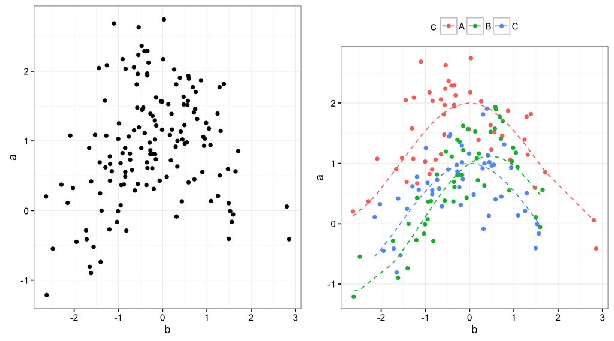

```r
library(ggplot2)
library(gridExtra)
p1 <- qplot(b, a)
p2 <- qplot(b, a, color = c) + geom_line(aes(y = mu), linetype = 2) +
  theme(legend.position = "top")
grid.arrange(p1, p2, ncol = 2)
```

**Question 1:** Fit a linear regression model to data generated as above with `a` the response variable and `b` the predictor. Investigate the residuals. Does the model fit the data?

## Model matrices

The linear regression model you fitted above was most likely fitted using `lm` with the formula `a ~ b`. This formula is used for the construction of a model matrix with two columns. A column of ones representing the intercept, and a column with the observed values of the predictor variable.

```r
model.matrix(a ~ b)[1:10, ]
```

```
##    (Intercept)           b
## 1            1 -0.00976291
## 2            1 -1.64998340
## 3            1 -0.32014201
## 4            1 -1.42256848
## 5            1  1.24188519
## 6            1  1.08065770
## 7            1 -0.34586390
## 8            1  0.16357737
## 9            1  1.04708832
## 10           1  0.33458702
```

**Question 2:** How do you get rid of the intercept?

If we “add” a factor on $k$ levels the model matrix gets $k-1$ additional columns. These are dummy variable encodings of the levels of the factor. The precise encoding is controlled by the `contrasts.arg` argument to `model.matrix` (the `contrasts` argument to `lm` or `glm`) or by setting the contrasts associated with a factor.

```r
model.matrix(a ~ b + c)[1:10, ]
```

```
##    (Intercept)           b cB cC
## 1            1 -0.00976291  0  0
## 2            1 -1.64998340  0  1
## 3            1 -0.32014201  0  0
## 4            1 -1.42256848  0  0
## 5            1  1.24188519  0  0
## 6            1  1.08065770  1  0
## 7            1 -0.34586390  0  0
## 8            1  0.16357737  1  0
## 9            1  1.04708832  1  0
## 10           1  0.33458702  0  1
```

```r
### We change the base level to be level 3 (value "C")
contrasts(c) <- contr.treatment(levels(c), base = 3)
model.matrix(a ~ b + c)[1:10, ]
```

```
##    (Intercept)           b cA cB
## 1            1 -0.00976291  1  0
## 2            1 -1.64998340  0  0
## 3            1 -0.32014201  1  0
## 4            1 -1.42256848  1  0
## 5            1  1.24188519  1  0
## 6            1  1.08065770  0  1
## 7            1 -0.34586390  1  0
## 8            1  0.16357737  0  1
## 9            1  1.04708832  0  1
## 10           1  0.33458702  0  0
```

A change of the dummy variable encoding does not change the model (the column space) only the parametrization. This may occasionally be useful for interpretation or for testing certain hypotheses.

**Question 3:** How can you check (numerically) that the two model matrices above span the same column space?

## Interactions

In formulas, the arithmetic operators `*` and `^` together with `:` have special meanings.

- Usage of `b * c` is equivalent `b + c + b : c`
- Usage of `b : c` formulates the interaction model.
- Usage of `(a + b + c)^2` is equivalent to `(a + b + c) * (a + b + c)` is equivalent to `a + b + c + a : b + a : c + b : c`, etc.

```r
model.matrix(a ~ c + b : c)[1:10, ]
```

```
##    (Intercept) cA cB        cA:b      cB:b      cC:b
## 1            1  1  0 -0.00976291 0.0000000  0.000000
## 2            1  0  0  0.00000000 0.0000000 -1.649983
## 3            1  1  0 -0.32014201 0.0000000  0.000000
## 4            1  1  0 -1.42256848 0.0000000  0.000000
## 5            1  1  0  1.24188519 0.0000000  0.000000
## 6            1  0  1  0.00000000 1.0806577  0.000000
## 7            1  1  0 -0.34586390 0.0000000  0.000000
## 8            1  0  1  0.00000000 0.1635774  0.000000
## 9            1  0  1  0.00000000 1.0470883  0.000000
## 10           1  0  0  0.00000000 0.0000000  0.334587
```

```r
model.matrix(a ~ b * c)[1:10, ]
```

```
##    (Intercept)           b cA cB        b:cA      b:cB
## 1            1 -0.00976291  1  0 -0.00976291 0.0000000
## 2            1 -1.64998340  0  0  0.00000000 0.0000000
## 3            1 -0.32014201  1  0 -0.32014201 0.0000000
## 4            1 -1.42256848  1  0 -1.42256848 0.0000000
## 5            1  1.24188519  1  0  1.24188519 0.0000000
## 6            1  1.08065770  0  1  0.00000000 1.0806577
## 7            1 -0.34586390  1  0 -0.34586390 0.0000000
## 8            1  0.16357737  0  1  0.00000000 0.1635774
## 9            1  1.04708832  0  1  0.00000000 1.0470883
## 10           1  0.33458702  0  0  0.00000000 0.0000000
```

**Question 4:** Are the two models above identical?

## Basis expansions

Transformations can be achieved by formally applying an R function to a variable in the formula specification. Expansions can be achieved if the R function returns a matrix and not a vector when applied to a vector.

```r
library(splines)
model.matrix(a ~ ns(b, df = 4))[1:10, ]
```

```
##    (Intercept) ns(b, df = 4)1 ns(b, df = 4)2 ns(b, df = 4)3 ns(b, df = 4)4
## 1            1     0.75361809    0.169569207     0.08775628    -0.04862859
## 2            1     0.07603605   -0.191091633     0.44504011    -0.25394848
## 3            1     0.77817043    0.005536704     0.13653515    -0.07790959
## 4            1     0.14168625   -0.207697339     0.48371373    -0.27601639
## 5            1     0.15040919    0.515081509     0.26234462     0.07216468
## 6            1     0.20011297    0.527404800     0.24317864     0.02930359
## 7            1     0.77081157   -0.006178401     0.14566091    -0.08311693
## 8            1     0.67272163    0.267697355     0.09868196    -0.04985923
## 9            1     0.21167677    0.528033336     0.23892089     0.02136900
## 10           1     0.57019120    0.357917704     0.12441563    -0.05377683
```

Before you run the R expression below answer the following question on the basis of what you have learned.

**Question 5:** Determine the number of columns for the model matrix below and explain and interpret what the columns mean?

```r
model.matrix(a ~ ns(b, df = 4) * c)[1:10, ]
```

## A linear model

The following figures were obtained by fitting the linear model using the model matrix, or rather the formula, from above. The fitted values plotted as lines on the left figure were obtained using the `fitted` function. The dashed lines are the true means. The right figure shows a residual plot.

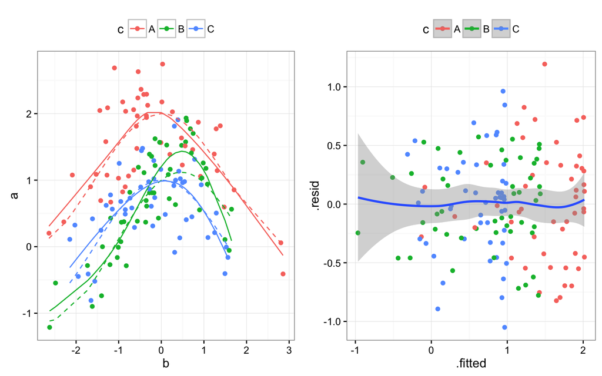

**Question 6:** Reproduce the figures. Use `geom_line` to add the fitted curves to the figure. Use `geom_smooth` to add the smooth of the residuals.